```python
%load_ext load_style
%load_style talk.css
```

# Numpy

```python
from IPython.display import Image, HTML
```

**Numpy** is the fundamental building block of the so-called **Python Scientific Stack**

- It provides a special data structure, the numpy **ndarray** (*N* - dimensional array) which allows the representation of arrays of numerical values, integers, reals, complex
- Numpy arrays by default can only hold objects of the same type (e.g. cannot mix integers and floats))
- It also provides with random number capability, some convenience simple statistical functions (mean, std, ...) and some essential linear algebra operations

```python
HTML("<iframe src='http://numpy.org/' width=1000 height=500></iframe>")
```

[interactive chart not shown]

The conventional way to import numpy is

```
import numpy as np
```

```python
import numpy as np
```

```python
import matplotlib.pyplot as plt
%matplotlib inline
```

## Numpy basics

Constructing an numpy array

```python
x = [1,2,3,4] # x is a regular python list
```

```python
type(x)
```

```
list
```

```python
x = np.array(x)
```

```python
type(x)
```

```
numpy.ndarray
```

```python
a = np.array(range(10))
```

```python
a
```

```
array([0, 1, 2, 3, 4, 5, 6, 7, 8, 9])
```

```python
x = [[1,2,3],[4,5,6]] # nested lists
```

```python
x = np.array(x)
```

```python
x
```

```
array([[1, 2, 3],
       [4, 5, 6]])
```

```python
x.shape
```

```
(2, 3)
```

The shape attribute is a tuple containing the dimensions along each **axis** (0 = rows, 1 = columns, ...)

```python
x = np.arange(1000).reshape((10,10,10))
```

```python
x.shape
```

```
(10, 10, 10)
```

**Be careful**: keep in mind **references** Vs. **copies** of arrays!

```python
a
```

```
array([0, 1, 2, 3, 4, 5, 6, 7, 8, 9])
```

```python
x = a
```

```python
x
```

```
array([0, 1, 2, 3, 4, 5, 6, 7, 8, 9])
```

```python
a[2] = 99
```

```python
a
```

```
array([ 0,  1, 99,  3,  4,  5,  6,  7,  8,  9])
```

```python
x
```

```
array([ 0,  1, 99,  3,  4,  5,  6,  7,  8,  9])
```

**x has changed !**, because x = a only means you create a new **reference** pointing to the **same object** as the array `a`

We can see that by using the `id` function, which returns the object's memory adress

```python
id(a)
```

```
4513687392
```

```python
id(x)
```

```
4513687392
```

If you want to create a **copy** instead of a **reference**, you need to do it explicitely

```python
x = a.copy()
```

```python
id(x)
```

```
4513689728
```

```python
a[3] = 888
```

```python
a
```

```
array([  0,   1,  99, 888,   4,   5,   6,   7,   8,   9])
```

```python
x
```

```
array([ 0,  1, 99,  3,  4,  5,  6,  7,  8,  9])
```

### Numpy array types

Numpy tries and guess the correct **type** of the numerical values if you pass a list, here x is of type integer 64

```python
x.dtype
```

```
dtype('int64')
```

You can change that using the method **astype()**

```python
x = x.astype(np.float)
```

```python
x.dtype
```

```
dtype('float64')
```

```python
x
```

```
array([  0.,   1.,  99.,   3.,   4.,   5.,   6.,   7.,   8.,   9.])
```

you can mix different types when creating an array from a list, but numpy will cast all values to the safest dtype

```python
x = np.array([1.0,1,1])
```

```python
x
```

```
array([ 1.,  1.,  1.])
```

You can (but why would you ?) create arrays of native Python types, i.e. here an array containing a dictionnary and a tuple

```python
x = np.array([{'A':1},(1,3)])
```

In that case the dtype is `Object` ('O')

```python
x
```

```
array([{'A': 1}, (1, 3)], dtype=object)
```

### Some convenience functions for creating arrays

np.arange(*start*, **stop**, *step*, *dtype=None*)

```python
np.arange(100).shape
```

```
(100,)
```

```python
np.arange(0,100+10,10)
```

```
array([  0,  10,  20,  30,  40,  50,  60,  70,  80,  90, 100])
```

`np.linspace(start, stop, num=50, *endpoint=True*, *retstep=False*)`

```python
np.linspace(0,0.5,10, endpoint=False)
```

```
array([ 0.  ,  0.05,  0.1 ,  0.15,  0.2 ,  0.25,  0.3 ,  0.35,  0.4 ,  0.45])
```

same as np.arange(0,0.5, 0.05)

```python
np.arange(0,0.5,0.05)
```

```
array([ 0.  ,  0.05,  0.1 ,  0.15,  0.2 ,  0.25,  0.3 ,  0.35,  0.4 ,  0.45])
```

`np.ones(shape, dtype=None, order='C')` creates an array of ones, similar function is np.zeros

```python
np.ones((10,12))
```

```
array([[ 1.,  1.,  1.,  1.,  1.,  1.,  1.,  1.,  1.,  1.,  1.,  1.],
       [ 1.,  1.,  1.,  1.,  1.,  1.,  1.,  1.,  1.,  1.,  1.,  1.],
       [ 1.,  1.,  1.,  1.,  1.,  1.,  1.,  1.,  1.,  1.,  1.,  1.],
       [ 1.,  1.,  1.,  1.,  1.,  1.,  1.,  1.,  1.,  1.,  1.,  1.],
       [ 1.,  1.,  1.,  1.,  1.,  1.,  1.,  1.,  1.,  1.,  1.,  1.],
       [ 1.,  1.,  1.,  1.,  1.,  1.,  1.,  1.,  1.,  1.,  1.,  1.],
       [ 1.,  1.,  1.,  1.,  1.,  1.,  1.,  1.,  1.,  1.,  1.,  1.],
       [ 1.,  1.,  1.,  1.,  1.,  1.,  1.,  1.,  1.,  1.,  1.,  1.],
       [ 1.,  1.,  1.,  1.,  1.,  1.,  1.,  1.,  1.,  1.,  1.,  1.],
       [ 1.,  1.,  1.,  1.,  1.,  1.,  1.,  1.,  1.,  1.,  1.,  1.]])
```

`np.empty` can be used to pre-allocate "empty" arrays with small memory footprint

```python
np.empty((5,5))
```

```
array([[  0.00000000e+000,  -1.36061851e-315,   2.22059011e-314,
          2.17900826e-314,   2.22012992e-314],
       [  2.17675082e-314,   2.17675021e-314,   2.12376936e-314,
          2.12376941e-314,   2.12376945e-314],
       [  2.12376949e-314,   2.12376954e-314,   2.16726425e-314,
          2.17751993e-314,   2.17868408e-314],
       [  2.17868442e-314,   2.17868447e-314,   2.17868451e-314,
          2.14029205e-314,   2.23003251e-314],
       [  2.14069146e-314,   2.23007322e-314,   2.14029205e-314,
          2.23006362e-314,   2.14047257e-314]])
```

## Array indexing

### Simple indexing

```python
a = np.arange(25,dtype=float).reshape(5,5) # creating a 2D array, note the dtype
```

```python
print(a)
```

```
[[  0.   1.   2.   3.   4.]
 [  5.   6.   7.   8.   9.]
 [ 10.  11.  12.  13.  14.]
 [ 15.  16.  17.  18.  19.]
 [ 20.  21.  22.  23.  24.]]
```

```python
a.shape
```

```
(5, 5)
```

```python
a[0,1] # FIRST row, SECOND column, remember, Python indexing is zero-based
```

```
1.0
```

```python
a[:,0] # first column
```

```
array([  0.,   5.,  10.,  15.,  20.])
```

```python
a[1,:] # second row
```

```
array([ 5.,  6.,  7.,  8.,  9.])
```

```python
a[:,2:] # all rows from third colum
```

```
array([[  2.,   3.,   4.],
       [  7.,   8.,   9.],
       [ 12.,  13.,  14.],
       [ 17.,  18.,  19.],
       [ 22.,  23.,  24.]])
```

```python
a[-1,:] # last row
```

```
array([ 20.,  21.,  22.,  23.,  24.])
```

```python
a[:,::-1] # handy: reverses column order
```

```
array([[  4.,   3.,   2.,   1.,   0.],
       [  9.,   8.,   7.,   6.,   5.],
       [ 14.,  13.,  12.,  11.,  10.],
       [ 19.,  18.,  17.,  16.,  15.],
       [ 24.,  23.,  22.,  21.,  20.]])
```

```python
a
```

```
array([[  0.,   1.,   2.,   3.,   4.],
       [  5.,   6.,   7.,   8.,   9.],
       [ 10.,  11.,  12.,  13.,  14.],
       [ 15.,  16.,  17.,  18.,  19.],
       [ 20.,  21.,  22.,  23.,  24.]])
```

slices allows to easily select **contiguous** row / colums

```python
a[0:2,1:3] # first two rows, and columns 2 to 3
```

```
array([[ 1.,  2.],
       [ 6.,  7.]])
```

When you want to select **non-contiguous** (or repeated) rows / columns, you can use the **ix_** construct

```python
a[np.ix_([0,1,3],[1,1,3])]
```

```
array([[  1.,   1.,   3.],
       [  6.,   6.,   8.],
       [ 16.,  16.,  18.]])
```

```python
a
```

```
array([[  0.,   1.,   2.,   3.,   4.],
       [  5.,   6.,   7.,   8.,   9.],
       [ 10.,  11.,  12.,  13.,  14.],
       [ 15.,  16.,  17.,  18.,  19.],
       [ 20.,  21.,  22.,  23.,  24.]])
```

### Boolean or conditional indexing

```python
a = a[a>10]
```

```python
print(a)
```

```
[ 11.  12.  13.  14.  15.  16.  17.  18.  19.  20.  21.  22.  23.  24.]
```

## Array broadcasting

### Simple possible case: scalar broadcasting

```python
x = np.array([0,1,2,3]); print(x)
```

```
[0 1 2 3]
```

```python
x.shape
```

```
(4,)
```

```python
x + 3
```

```
array([3, 4, 5, 6])
```

![](images/broadcast_scalar.png)

### 2D broadcasting

```python
x = np.arange(12).reshape((3,4))
```

```python
x
```

```
array([[ 0,  1,  2,  3],
       [ 4,  5,  6,  7],
       [ 8,  9, 10, 11]])
```

```python
x.shape
```

```
(3, 4)
```

```python
y = np.arange(3).reshape((3,1)); # or y = np.arange(3)[np.newaxis,:] or y = np.arange(3)[None,:]
```

```python
y.shape
```

```
(3, 1)
```

```python
x + y
```

```
array([[ 0,  1,  2,  3],
       [ 5,  6,  7,  8],
       [10, 11, 12, 13]])
```

![](images/broadcast_2D.png)

### 3D broadcasting

```python
x = np.arange(15).reshape((3, 5))
```

```python
x.shape
```

```
(3, 5)
```

```python
y = np.ones(8)
```

```python
z = x[...,np.newaxis] + y
```

```python
print(z)
```

```
[[[  1.   1.   1.   1.   1.   1.   1.   1.]
  [  2.   2.   2.   2.   2.   2.   2.   2.]
  [  3.   3.   3.   3.   3.   3.   3.   3.]
  [  4.   4.   4.   4.   4.   4.   4.   4.]
  [  5.   5.   5.   5.   5.   5.   5.   5.]]

 [[  6.   6.   6.   6.   6.   6.   6.   6.]
  [  7.   7.   7.   7.   7.   7.   7.   7.]
  [  8.   8.   8.   8.   8.   8.   8.   8.]
  [  9.   9.   9.   9.   9.   9.   9.   9.]
  [ 10.  10.  10.  10.  10.  10.  10.  10.]]

 [[ 11.  11.  11.  11.  11.  11.  11.  11.]
  [ 12.  12.  12.  12.  12.  12.  12.  12.]
  [ 13.  13.  13.  13.  13.  13.  13.  13.]
  [ 14.  14.  14.  14.  14.  14.  14.  14.]
  [ 15.  15.  15.  15.  15.  15.  15.  15.]]]
```

```python
z.shape
```

```
(3, 5, 8)
```

![](images/array_3x5x8.png)

## Array methods

We have already seen some array methods above, in this section I just dwelve into their general behavior and present some convenient array methods

In python, everything is an **object**, numpy ndarrays are no exceptions, and they expose a number of **methods**, which are equivalent to the call the respective numpy function, but can be more convenient to use, and - marginally - faster

```python
a.shape # shape of a (like *size* in matlab)
```

```
(14,)
```

```python
np.shape(a)
```

```
(14,)
```

```python
%timeit a.mean() # The %timeit magic cell function times the execution of an expression
```

```
The slowest run took 13.57 times longer than the fastest. This could mean that an intermediate result is being cached.
100000 loops, best of 3: 4.27 µs per loop
```

```python
%timeit np.mean(a)
```

```
The slowest run took 8.76 times longer than the fastest. This could mean that an intermediate result is being cached.
100000 loops, best of 3: 5.27 µs per loop
```

```python
b = np.arange(100,dtype=float).reshape(10,10) # creating a 2D array, note the dtype
```

```python
b.shape
```

```
(10, 10)
```

```python
b
```

```
array([[  0.,   1.,   2.,   3.,   4.,   5.,   6.,   7.,   8.,   9.],
       [ 10.,  11.,  12.,  13.,  14.,  15.,  16.,  17.,  18.,  19.],
       [ 20.,  21.,  22.,  23.,  24.,  25.,  26.,  27.,  28.,  29.],
       [ 30.,  31.,  32.,  33.,  34.,  35.,  36.,  37.,  38.,  39.],
       [ 40.,  41.,  42.,  43.,  44.,  45.,  46.,  47.,  48.,  49.],
       [ 50.,  51.,  52.,  53.,  54.,  55.,  56.,  57.,  58.,  59.],
       [ 60.,  61.,  62.,  63.,  64.,  65.,  66.,  67.,  68.,  69.],
       [ 70.,  71.,  72.,  73.,  74.,  75.,  76.,  77.,  78.,  79.],
       [ 80.,  81.,  82.,  83.,  84.,  85.,  86.,  87.,  88.,  89.],
       [ 90.,  91.,  92.,  93.,  94.,  95.,  96.,  97.,  98.,  99.]])
```

```python
b.sum(0) ### summing over the first axis ('rows')
```

```
array([ 450.,  460.,  470.,  480.,  490.,  500.,  510.,  520.,  530.,  540.])
```

```python
np.sum(b, axis=0)
```

```
array([ 450.,  460.,  470.,  480.,  490.,  500.,  510.,  520.,  530.,  540.])
```

```python
b[:,0].sum()
```

```
450.0
```

*swapaxes* method swap the position of 2 axes

```python
b = b.swapaxes(1,0)
```

```python
b
```

```
array([[  0.,  10.,  20.,  30.,  40.,  50.,  60.,  70.,  80.,  90.],
       [  1.,  11.,  21.,  31.,  41.,  51.,  61.,  71.,  81.,  91.],
       [  2.,  12.,  22.,  32.,  42.,  52.,  62.,  72.,  82.,  92.],
       [  3.,  13.,  23.,  33.,  43.,  53.,  63.,  73.,  83.,  93.],
       [  4.,  14.,  24.,  34.,  44.,  54.,  64.,  74.,  84.,  94.],
       [  5.,  15.,  25.,  35.,  45.,  55.,  65.,  75.,  85.,  95.],
       [  6.,  16.,  26.,  36.,  46.,  56.,  66.,  76.,  86.,  96.],
       [  7.,  17.,  27.,  37.,  47.,  57.,  67.,  77.,  87.,  97.],
       [  8.,  18.,  28.,  38.,  48.,  58.,  68.,  78.,  88.,  98.],
       [  9.,  19.,  29.,  39.,  49.,  59.,  69.,  79.,  89.,  99.]])
```

here equivalent to *transpose()* on 2D array

```python
b = b.transpose()
```

```python
b
```

```
array([[  0.,   1.,   2.,   3.,   4.,   5.,   6.,   7.,   8.,   9.],
       [ 10.,  11.,  12.,  13.,  14.,  15.,  16.,  17.,  18.,  19.],
       [ 20.,  21.,  22.,  23.,  24.,  25.,  26.,  27.,  28.,  29.],
       [ 30.,  31.,  32.,  33.,  34.,  35.,  36.,  37.,  38.,  39.],
       [ 40.,  41.,  42.,  43.,  44.,  45.,  46.,  47.,  48.,  49.],
       [ 50.,  51.,  52.,  53.,  54.,  55.,  56.,  57.,  58.,  59.],
       [ 60.,  61.,  62.,  63.,  64.,  65.,  66.,  67.,  68.,  69.],
       [ 70.,  71.,  72.,  73.,  74.,  75.,  76.,  77.,  78.,  79.],
       [ 80.,  81.,  82.,  83.,  84.,  85.,  86.,  87.,  88.,  89.],
       [ 90.,  91.,  92.,  93.,  94.,  95.,  96.,  97.,  98.,  99.]])
```

```python
b = np.transpose(b)
```

```python
b
```

```
array([[  0.,  10.,  20.,  30.,  40.,  50.,  60.,  70.,  80.,  90.],
       [  1.,  11.,  21.,  31.,  41.,  51.,  61.,  71.,  81.,  91.],
       [  2.,  12.,  22.,  32.,  42.,  52.,  62.,  72.,  82.,  92.],
       [  3.,  13.,  23.,  33.,  43.,  53.,  63.,  73.,  83.,  93.],
       [  4.,  14.,  24.,  34.,  44.,  54.,  64.,  74.,  84.,  94.],
       [  5.,  15.,  25.,  35.,  45.,  55.,  65.,  75.,  85.,  95.],
       [  6.,  16.,  26.,  36.,  46.,  56.,  66.,  76.,  86.,  96.],
       [  7.,  17.,  27.,  37.,  47.,  57.,  67.,  77.,  87.,  97.],
       [  8.,  18.,  28.,  38.,  48.,  58.,  68.,  78.,  88.,  98.],
       [  9.,  19.,  29.,  39.,  49.,  59.,  69.,  79.,  89.,  99.]])
```

argsort, argmin and argmax returns the indices that would sort an array (along an axis), and the indices of min and max values

```python
a = np.array([11,13,15,17,19,18,16,14,12,10])
```

```python
a.argsort()
```

```
array([9, 0, 8, 1, 7, 2, 6, 3, 5, 4])
```

```python
a.sort(); print(a)
```

```
[10 11 12 13 14 15 16 17 18 19]
```

### array functions

we've seen above array `methods`, available through the object-oriented interface of Python, now we're gonna see a few useful numpy `functions`

```python
from scipy import misc
```

```python
img = misc.ascent()
```

```python
img.shape
```

```
(512, 512)
```

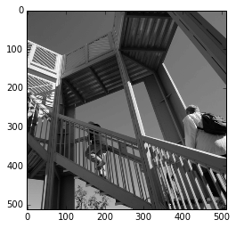

```python
plt.imshow(img, cmap=plt.get_cmap('gray'))
```

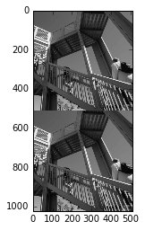

```python
plt.imshow(np.tile(img, (2,1)), cmap=plt.get_cmap('gray'))
```

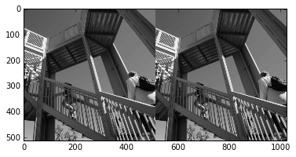

```python
plt.imshow(np.tile(img, (1,2)), cmap=plt.get_cmap('gray'))
```

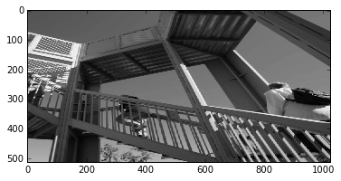

```python
plt.imshow(np.repeat(img, 2, axis=1), cmap=plt.get_cmap('gray'))
```

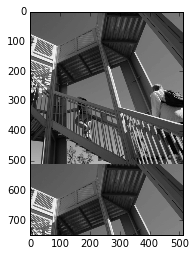

```python
plt.imshow(np.resize(img, (750,512)), cmap=plt.get_cmap('gray'))
```

### Universal functions

A universal function (or ufunc for short) is a function that operates on ndarrays in an element-by-element fashion, supporting array broadcasting, type casting, and several other standard features. That is, a ufunc is a “vectorized” wrapper for a function that takes a fixed number of scalar inputs and produces a fixed number of scalar outputs.

```python
x = np.sin(np.linspace(-2*np.pi, 2*np.pi, 10000).reshape((100,100)))
```

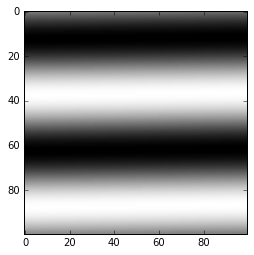

```python
plt.imshow(x, cmap=plt.get_cmap('gray_r'))
```

vectorization

```python
def max100(x):
    """
    returns the max between x and 100
    """

    return(max(x,100))
```

```python
x = np.random.normal(loc=50, scale=100, size=(10,10))
```

```python
x
```

```
array([[-132.02791772,   10.51258305,  -18.26165165,   29.52551808,
          49.90137487, -114.56933026,   37.52395926,   18.26046363,
         181.49974374,  -23.17326832],
       [  70.83452231,   95.44874015,    9.43919499,   -6.45709375,
          37.7043529 ,  116.5546573 ,  -58.53156427,    5.25969761,
         142.05300278,  163.62635372],
       [   1.22172059,   20.44116229,   -9.39156418,  140.77742491,
         116.74690273,   62.94611579,   -4.1467985 ,  -20.63352293,
         -68.79900156,  -39.59058175],
       [ 112.30518901,   52.63486447,  -88.65076672,  148.49007476,
         -25.07034234,  -50.91106126,   78.95163466,   31.41969396,
          19.12567454,  -20.73918665],
       [ -46.92489266,  103.41024651,  103.61225672,  103.07641847,
         184.5888961 ,  318.42347116,  -96.94233514,  101.50135546,
          15.11964787,  -11.40184138],
       [ 157.73038713,   72.42858157,   41.99863723,  151.0249878 ,
          18.28485292,  109.37960676,   38.61112069,  106.75363974,
          44.00770946,  181.67068892],
       [-170.17340253,   92.31105752,  162.16019279,   53.59646741,
         -25.26177166,  141.88780162, -147.5141566 ,  202.40452535,
          44.36366853,   -2.82842534],
       [   2.81461595,  229.25965522,   86.7647738 , -119.35928661,
         140.07003304,  -94.91265824,  -36.89661325,   88.47760476,
         127.63100361, -121.62074822],
       [  66.31611858,  -53.77781637,   33.79721792,  178.21249135,
         216.50609091,  248.00924699,  292.82929856,   66.13651437,
          91.05180128,   14.28951509],
       [ 217.32338121,   81.59506434,   87.75000077,   94.30310696,
         104.8537877 ,   14.2911185 ,    2.37125674,   84.88291132,
        -141.17740182,  112.77763097]])
```

```python
max100(x)
```

```
---------------------------------------------------------------------------
ValueError                                Traceback (most recent call last)
<ipython-input-107-156bf71d3f74> in <module>()
----> 1 max100(x)

<ipython-input-104-f7f82149988e> in max100(x)
      4     """
      5
----> 6     return(max(x,100))

ValueError: The truth value of an array with more than one element is ambiguous. Use a.any() or a.all()
```

that fails because max100 is just a regular python function, that expects a single object

but we can build easily a `vectorized` version of the same function (i.e. building a `ufunc`mm)

```python
vmax100 = np.vectorize(max100)
```

```python
z = vmax100(x)
```

```python
z.shape
```

```
(10, 10)
```

```python
z
```

```
array([[100, 100, 100, 100, 100, 100, 100, 100, 181, 100],
       [100, 100, 100, 100, 100, 116, 100, 100, 142, 163],
       [100, 100, 100, 140, 116, 100, 100, 100, 100, 100],
       [112, 100, 100, 148, 100, 100, 100, 100, 100, 100],
       [100, 103, 103, 103, 184, 318, 100, 101, 100, 100],
       [157, 100, 100, 151, 100, 109, 100, 106, 100, 181],
       [100, 100, 162, 100, 100, 141, 100, 202, 100, 100],
       [100, 229, 100, 100, 140, 100, 100, 100, 127, 100],
       [100, 100, 100, 178, 216, 248, 292, 100, 100, 100],
       [217, 100, 100, 100, 104, 100, 100, 100, 100, 112]])
```

Numpy provides a number of already vectorized mathematical functions (`ufuncs` again). e.g. `round`, `fix` and all basic trigonometric (`sin, cos, tan, sic`), exponential (`exp, exp2, sinh, cosh`), and logarithmic functions (`log, log10, log2`).